# NetCDF - Low Level usage in R

## R packages for NetCDF

- RNetCDF
- ncdf
- ncdf4
- rgdal

## Typical session

```r
dp <- "~/ncdata"
f <- "avhrr-only-v2_20140301.nc"
library(RNetCDF)
nc <- open.nc(file.path(dp, f))
print.nc(nc)
## do other stuff
close.nc(nc)
```

Source file has variables **sst** as well as **anom**, **err**, and **ice**.

Daily sea surface temperature, Reynolds, et al.(2007) Daily High-resolution Blended Analyses.

avhrr-only-v2_20140301.ncdump

## Now what?

Proceed with gay abandon. (Beware of large variables.)

```r
nc <- open.nc(file.path(dp, f))
lons <- var.get.nc(nc, "lon")
lats <- var.get.nc(nc, "lat")
dat <- var.get.nc(nc, "sst")
range(dat, na.rm = TRUE)
```

```
## [1] -180 3129
```

- It's rarely simple.
- Inspect output of ncdump.
- Check data ranges, orientation, missing values.
- Code can interrogate **attributes** (the metadata) for sophisticated automation.

## Checks and visualization

Extremely important for checking assumptions/results.

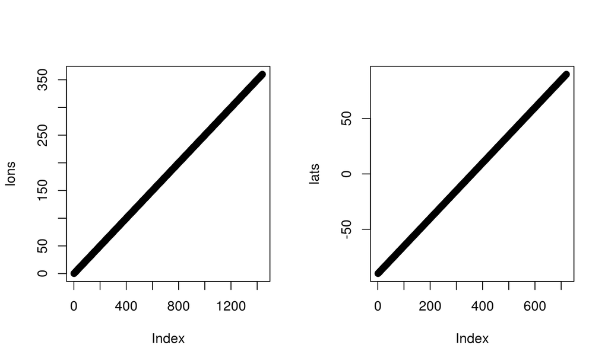

```r
m <- matrix(c(1, 2), 1, 2); layout(m)
plot(lons)
plot(lats)
```

## Visualization

Image of the raw matrix.

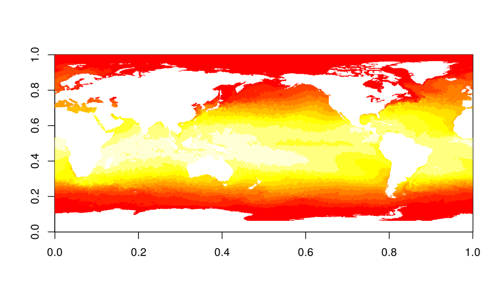

```r
image(dat)
```

## Reading subsets

```r
xindex <- which(lons >= 130 & lons <= 190)
yindex <- which(lats >= -65 & lats <= -20)
lons2 <- var.get.nc(nc, "lon", start = xindex[1], count = length(xindex))
lats2 <- var.get.nc(nc, "lat", start = yindex[1], count = length(yindex))
```

```r
## WATCH OUT - degenerate dimensions (starts at 1, has length 1)
indexstart <- c(xindex[1], yindex[2], 1, 1)
indexcount <- c(length(xindex), length(yindex), 1, 1)
dat2 <- var.get.nc(nc, "sst", start = indexstart, count = indexcount)
```

## Visualization

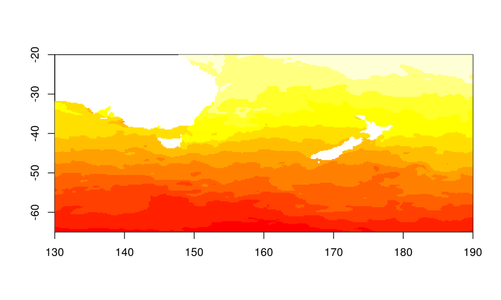

```r
d <- list(x = lons2, y = lats2, z = dat2)
image(d)
```

## Bumps in the road

- multiple variables in one file, or across files

```r
## horizontal and vertical components of velocity
fu <- "uwnd.10m.gauss.2013.nc"
fv <- "vwnd.10m.gauss.2013.nc"

unc <- open.nc(file.path(dp, fu))
## should check the "v" file has the same stuff
vnc <- open.nc(file.path(dp, fv))
```

Daily Forecast of U[V]-wind at 10 m, NCEP/DOE AMIP-II Reanalysis (Reanalysis-2) Daily Averages.

## Bumps in the road

- latitude top-down (was bottom-up for SST)
- longitude is Pacific-view (could be Atlantic [-180, 180])

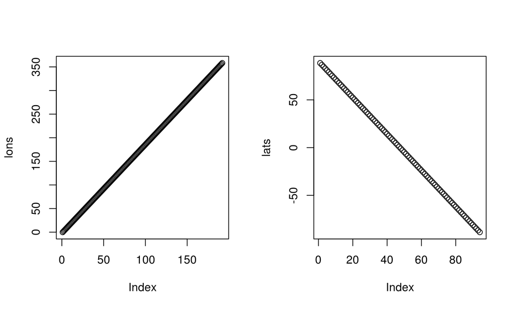

```r
lons <- var.get.nc(unc, "lon"); lats <- var.get.nc(unc, "lat")
layout(matrix(c(1, 2), 1, 2)); plot(lons); plot(lats)
```